# Advent of Code - December 2021

The [Advent of Code](https://adventofcode.com/) is a daily challenge series that has two puzzles each day. You get a star for each puzzle solved. Try to get all 50!

# Introduction

You’re minding your own business on a ship at sea when the overboard alarm goes off! You rush to see if you can help. Apparently, one of the Elves tripped and accidentally sent the sleigh keys flying into the ocean!

Before you know it, you’re inside a submarine the Elves keep ready for situations like this. It’s covered in Christmas lights (because of course it is), and it even has an experimental antenna that should be able to track the keys if you can boost its signal strength high enough; there’s a little meter that indicates the antenna’s signal strength by displaying 0-50 stars.

Your instincts tell you that in order to save Christmas, you’ll need to get all fifty stars by December 25th.

Collect stars by solving puzzles. Two puzzles will be made available on each day in the Advent calendar; the second puzzle is unlocked when you complete the first. Each puzzle grants one star. Good luck!

As the submarine drops below the surface of the ocean, it automatically performs a sonar sweep of the nearby sea floor. On a small screen, the sonar sweep report (your puzzle input) appears: each line is a measurement of the sea floor depth as the sweep looks further and further away from the submarine.

# Day 1: Sonar Sweep

The first order of business is to figure out how quickly the depth increases, just so you know what you’re dealing with - you never know if the keys will get carried into deeper water by an ocean current or a fish or something.

## Puzzle 1

To do this, count the number of times a depth measurement increases from the previous measurement. (There is no measurement before the first measurement.)

```r
depth2 <- depth %>%
  mutate(prev_val = lag(depth),
         change = ifelse(prev_val < depth, "Increased", "Decreased"))

sum_table <- depth2 %>% count(change)

sum_table %>% flextable()
```

| change | n |
| --- | --- |
| Decreased | 553 |
| Increased | 1,446 |
|  | 1 |

The answer to the first puzzle is **1446**. ⭐

## Puzzle 2

Consider sums of a three-measurement sliding window. How many sums are larger than the previous sum?

```r
depth3 <- depth2 %>%
  mutate(sum_val_3 = depth + lead(depth, n = 1) + lead(depth, n = 2),
         prev_sum = lag(sum_val_3),
         change_sum = ifelse(prev_sum < sum_val_3, "Increased", "Decreased"))

sum_table2 <- depth3 %>% count(change_sum)

sum_table2 %>% flextable()
```

| change_sum | n |
| --- | --- |
| Decreased | 511 |
| Increased | 1,486 |
|  | 3 |

The answer to the second puzzle is **1486**. ⭐

## David Robinson’s ([@drob](https://twitter.com/drob)) answers

```r
x <- as.vector(depth$depth)  # he probably just imported as a vector

sum(x > lag(x), na.rm = TRUE)
```

```
## [1] 1446
```

```r
sum(x > lag(x, n = 3), na.rm = TRUE)
```

```
## [1] 1486
```

# Day 2: Dive!

Calculate the horizontal position and depth you would have after following the planned course. What do you get if you multiply your final horizontal position by your final depth?

## Puzzle 1

It seems like the submarine can take a series of commands like forward 1, down 2, or up 3:

- forward X increases the horizontal position by X units.
- down X increases the depth by X units.
- up X decreases the depth by X units.

```r
d2_dt <- d2 %>% as_tibble() %>%
  separate(value, into = c("direction", "distance"), sep = " ") %>%
  mutate(distance = as.numeric(distance))



location <- d2_dt %>%
  group_by(direction) %>%
  summarize(across(distance, sum))

location %>% flextable()
```

| direction | distance |
| --- | --- |
| down | 1,985 |
| forward | 1,925 |
| up | 1,106 |

## Puzzle 2

In addition to horizontal position and depth, you’ll also need to track a third value, aim, which also starts at 0. The commands also mean something entirely different than you first thought:

- down X increases your aim by X units.
- up X decreases your aim by X units.
- forward X does two things:
  - It increases your horizontal position by X units.
  - It increases your depth by your aim multiplied by X.

```r
sum_aim <- d2_dt %>%
  mutate(x = case_when(direction == "forward" ~ 1,
                       TRUE ~ 0),
         y = case_when(direction == "up" ~ -1,
                       direction == "down" ~ 1,
                       TRUE ~ 0)) %>%
  mutate(aim = cumsum(distance * y)) %>%
  summarize(horizontal = sum(distance * x),
            depth = sum(distance * aim * x),
            product = depth * horizontal)
```

## DR answer

```r
directions <- tribble(
  ~ direction, ~ x, ~ y,
  "down", 0, 1,
  "up", 0, -1,
  "forward", 1, 0
)

joined <- d2_dt %>%
  inner_join(directions, by = "direction")


# Puzzle 1
joined %>%
  summarize(horizontal = sum(distance * x),
            depth = sum(distance * y),
            product = horizontal * depth)
```

```
## # A tibble: 1 x 3
##   horizontal depth product
##        <dbl> <dbl>   <dbl>
## 1       1925   879 1692075
```

```r
# Puzzle 2
joined %>%
  mutate(aim = cumsum(y * distance)) %>%
  summarize(horizontal = sum(distance * x),
            depth = sum(aim * distance * x),
            product = horizontal * depth)
```

```
## # A tibble: 1 x 3
##   horizontal  depth    product
##        <dbl>  <dbl>      <dbl>
## 1       1925 908844 1749524700
```

# Day 3: Binary Diagnostic

The submarine has been making some odd creaking noises, so you ask it to produce a diagnostic report just in case.

The diagnostic report (your puzzle input) consists of a list of binary numbers which, when decoded properly, can tell you many useful things about the conditions of the submarine. The first parameter to check is the power consumption.

## Puzzle 1

You need to use the binary numbers in the diagnostic report to generate two new binary numbers (called the gamma rate and the epsilon rate). The power consumption can then be found by multiplying the gamma rate by the epsilon rate.

Use the binary numbers in your diagnostic report to calculate the gamma rate and epsilon rate, then multiply them together. What is the power consumption of the submarine? (Be sure to represent your answer in decimal, not binary.)

Answer #1: **4147524** ⭐

## Puzzle 2

```r
ox_bi <- d3_mat %>%
  as.data.frame() %>%
  filter(V1 == most_common[1]) %>%
  filter(V2 == round(mean(.$V2) + 1e-6)) %>%
  filter(V3 == round(mean(.$V3) + 1e-6)) %>%
  filter(V4 == round(mean(.$V4) + 1e-6)) %>%
  filter(V5 == round(mean(.$V5) + 1e-6)) %>%
  filter(V6 == round(mean(.$V6) + 1e-6)) %>%
  filter(V7 == round(mean(.$V7) + 1e-6)) %>%
  filter(V8 == round(mean(.$V8) + 1e-6)) %>%
  filter(V9 == round(mean(.$V9) + 1e-6)) %>%
  filter(V10 == round(mean(.$V10) + 1e-6)) %>%
  filter(V11 == round(mean(.$V11) + 1e-6)) %>%
  filter(V12 == 1)

co2_bi <- d3_mat %>%
  as.data.frame() %>%
  filter(V1 == least_common[1]) %>%
  filter(V2 != round(mean(.$V2) + 1e-6)) %>%
  filter(V3 != round(mean(.$V3) + 1e-6)) %>%
  filter(V4 != round(mean(.$V4) + 1e-6)) %>%
  filter(V5 != round(mean(.$V5) + 1e-6)) %>%
  filter(V6 != round(mean(.$V6) + 1e-6)) %>%
  filter(V7 != round(mean(.$V7) + 1e-6)) %>%
  filter(V8 != round(mean(.$V8) + 1e-6)) %>%
  filter(V9 != 1)

oxygen <- strtoi(paste0(ox_bi, collapse = ""), base = 2)

co2 <- paste0(co2_bi, collapse = "") %>% strtoi(base = 2)

oxygen * co2
```

```
## [1] 3570354
```

Answer #2: **3570354** ⭐

## DR answer

```r
to_decimal <- function(x) {
  strtoi(paste0(x, collapse = ""), base = 2)
}

mat <- str_split(d3_df$V1, "") %>%
  map(as.integer) %>%
  do.call(rbind, .)

most_common <- round(colMeans(mat))

to_decimal(most_common) * to_decimal(1 - most_common)
```

```
## [1] 4147524
```

```r
filter_matrix <- function(m, index, most_common = TRUE) {
  target <- round(mean(m[, index]) + 1e-6)  # to round up

  if (!most_common) {
    target <- 1 - target
  }

  ret <- m[m[, index] == target, ]

  # Extracting one row from a matrix makes it a vector
  if (!is.matrix(ret)) {
    done(ret)
  } else {
    ret
  }
}

oxygen <- reduce(1:12, filter_matrix, .init = mat)

co2 <- reduce(1:12, filter_matrix, .init = mat, most_common = FALSE)

to_decimal(oxygen) * to_decimal(co2)
```

```
## [1] 3570354
```

# Day 4: Giant Squid

I couldn’t figure this one out on my own so I used @drob’s answer

```r
# browseURL("https://twitter.com/drob/status/1467157923512127488/photo/1")

d4_nos <- as.integer(d4_nos)

boards <- d4 %>%
  group_by(card_id) %>%
  mutate(row = row_number()) %>%
  separate_rows(cards, sep = " +", convert = TRUE) %>%
  group_by(card_id, row) %>%
  mutate(col = row_number()) %>%
  ungroup() %>%
  mutate(turn = match(cards, d4_nos))


board_turn_win <- boards %>%
  gather(coordinate, cards, row, col) %>%
  group_by(card_id, coordinate, cards) %>%
  summarize(complete_on_turn = max(turn)) %>%
  group_by(card_id) %>%
  summarize(win_on_turn = min(complete_on_turn))

board_scores <- board_turn_win %>%
  inner_join(boards, by = "card_id") %>%
  group_by(card_id, win_on_turn) %>%
  summarize(total_undrawn = sum(cards[turn > win_on_turn]),
            .groups = "drop") %>%
  mutate(answer = d4_nos[win_on_turn] * total_undrawn)

board_scores %>%
  slice_min(win_on_turn)
```

```
## # A tibble: 1 x 4
##   card_id win_on_turn total_undrawn answer
##     <int>       <int>         <int>  <int>
## 1      41          21           829  14093
```

Answer #1: **14093** ⭐

## Puzzle #2

```r
board_scores %>%
  slice_max(win_on_turn)
```

```
## # A tibble: 1 x 4
##   card_id win_on_turn total_undrawn answer
##     <int>       <int>         <int>  <int>
## 1      63          84           483  17388
```

Answer #2: **17388** ⭐

# Day 5: Hydrothermal Venture

## Puzzle #1

```r
d5 <- import(here("data", "aoc", "d5.xlsx"))

d5 %>%
  filter(x1 == x2 | y1 == y2) %>%
  mutate(x = map2(x1, x2, seq)) %>%
  mutate(y = map2(y1, y2, seq)) %>%
  unnest(c(x,y)) %>%
  count(x, y) %>%
  summarize(sum(n > 1))
```

```
## # A tibble: 1 x 1
##   `sum(n > 1)`
##          <int>
## 1         4745
```

Answer #1: **4745** ⭐

## Puzzle #2

```r
d5 %>%
#  filter(x1 == x2 | y1 == y2) %>%
  mutate(x = map2(x1, x2, seq)) %>%
  mutate(y = map2(y1, y2, seq)) %>%
  unnest(c(x,y)) %>%
  count(x, y) %>%
  summarize(sum(n > 1))
```

```
## # A tibble: 1 x 1
##   `sum(n > 1)`
##          <int>
## 1        18442
```

Answer #1: **18442** ⭐

# Day 6: Lanternfish

## Puzzle #1

```r
# browseURL("https://selbydavid.com/2021/12/01/advent-2021/")

d6 <- import(here("data", "aoc", "d6.xlsx"))

fish_0 <- as.vector(d6$timer)

fish_count <- function(x, days = 80) {
  fish <- as.double(table(factor(x, levels = 0:8)))

  for (i in 1:days)
    fish <-  c(fish[2:7], fish[8] + fish[1], fish[9], fish[1])
  sum(fish)
}

fish_count(fish_0, days = 80)
```

```
## [1] 374994
```

Answer #1: **374994** ⭐

## Puzzle #2

```r
options(scipen = 999)

fish_count(fish_0, days = 256)
```

```
## [1] 1686252324092
```

Answer #2: **1686252324092** ⭐

# Day 7: The Treachery of Whales

## Puzzle #1

```r
d7 <- import(here("data", "aoc", "d7.xlsx"))

mean_loc <- floor(mean(d7$position)) # tried floor() and ceiling()
median_loc <- round(median(d7$position))

crabs <- d7 %>%
  mutate(fuel_median = case_when(position < median_loc ~ median_loc - position,
                          position >= median_loc ~ position - median_loc),
         fuel_median_2 = abs(median_loc - position))  # shorter

sum(crabs$fuel_median)
```

```
## [1] 349769
```

Answer #1:

**349769** ⭐

## Puzzle #2

```r
crabs <- crabs %>%
  mutate(fuel_mean = abs(mean_loc - position),
         fuel_cost = fuel_mean / 2 * (1 + fuel_mean))

sum(crabs$fuel_cost)
```

```
## [1] 99540554
```

Answer #2:

**99540554** ⭐

# Day 8: Seven Segment Search

## Puzzle #1

```r
d8 <- import(here("data", "aoc", "d8.xlsx")) %>%
  mutate(entry = row_number(), .before = 1)

sum_table <- d8 %>%
  summarize(across(o1:o4, ~ nchar(.))) %>%
  pivot_longer(everything()) %>%
  count(value)

sum(sum_table$n[c(1, 2, 3, 6)])
```

```
## [1] 514
```

Answer #1: **514** ⭐

## Puzzle #2

# Day 9: Smoke Basin

## Puzzle #1

```r
input <- advent_input(9)


x <- input %>%
  mutate(row = row_number()) %>%
  mutate(value = str_split(x, "")) %>%
  unnest(value) %>%
  mutate(value = as.numeric(value)) %>%
  group_by(row) %>%
  mutate(col = row_number()) %>%
  ungroup()

adj <- tibble(xd = c(-1, 1, 0, 0),
              yd = c(0, 0, -1, 1))

adjacent <- function(d, d2) {
  d %>%
    crossing(adj) %>%
    mutate(row2 = row + xd,
           col2 = col + yd) %>%
    inner_join(d2, by = c(row2 = "row", col2 = "col"), suffix = c("", "2")) %>%
    filter(row != row2 | col != col2)
}
```

```r
low_points <- x %>%
  adjacent(x) %>%
  group_by(row, col) %>%
  summarize(low = all(value < value2)) %>%
  filter(low) %>%
  inner_join(x, by = c("row", "col")) %>%
  ungroup()

low_points %>%
  summarize(sum(1 + value))
```

```
## # A tibble: 1 x 1
##   `sum(1 + value)`
##              <dbl>
## 1              494
```

Answer #1: **494** ⭐

## Puzzle #2

```r
frontier <- low_points %>%
  mutate(basin = paste(row, col)) %>%
  select(basin, row, col, value)

basins <- frontier

while (nrow(frontier) > 0) {
  frontier <- frontier %>%
    adjacent(x) %>%
    filter(value2 > value, value2 < 9) %>%
    select(basin, row = row2, col = col2, value = value2) %>%
    distinct(basin, row, col, .keep_all = TRUE) %>%
    anti_join(basins, by = c("row", "col"))

  basins <- bind_rows(basins, frontier)
}

basins %>%
  count(basin, sort = TRUE) %>%
  head(3) %>%
  summarize(prod(n))
```

```
## # A tibble: 1 x 1
##   `prod(n)`
##       <dbl>
## 1   1048128
```

Answer #2: **1048128** ⭐

# Day 10: Syntax Scoring

## Puzzle #1

```r
# browseURL("https://pbs.twimg.com/media/FGRdRyWXIAUx3vw?format=jpg&name=large")

input <- advent_input(10)

d10 <- read_lines(here("data", "aoc", "d10.txt"))

corruption_values <- c(")" = 3, "]" = 57, "}" = 1197, ">" = 25137)

opening <- c("(", "[", "{", "<")
closing <- c(")", "]", "}", ">")

opening_matches <- opening
names(opening_matches) <- closing

is_match <- function(x, current) {
  if (length(x) == 0) return(FALSE)
  current %in% closing && tail(x, 1) == opening_matches[current]
}

is_corrupt <- function(x, current) {
  if (length(x) == 0) return(FALSE)
  current %in% closing && opening_matches[current] != tail(x, 1)
}

test <- input %>% slice(54)

nchar(test)
```

```
##  x
## 94
```

```r
corruption_value <- function(line) {
  chars <- line %>% str_split("") %>% .[[1]]

  x <- c()
  next_char_idx <- 1

  while (next_char_idx <= length(chars) && !is_corrupt(x, chars[next_char_idx])) {
    if (is_match(x, chars[next_char_idx])) {
      x <- head(x, length(x) - 1)
    } else {
      x <- c(x, chars[next_char_idx])
    }

    next_char_idx <- next_char_idx + 1
  }

  if (!next_char_idx > length(chars)) {
    value <- corruption_values[chars[next_char_idx]]
  } else {
    value <- 0
  }

  return(value)
}
```

Answer #1: **341823** ⭐

## Puzzle #2

```r
completion_values <- c("(" = 1, "[" = 2, "{" = 3, "<" = 4)

incomplete_lines <- keep(d10, .p = ~{corruption_value(.x) == 0})

completion_value <- function(line) {
  chars <- line %>% str_split("") %>% .[[1]]

  x <- c()
  next_char_idx <- 1

  while (next_char_idx <= length(chars)) {
    if (is_match(x, chars[next_char_idx])) {
      x <- head(x, length(x) - 1)
    } else {
      x <- c(x, chars[next_char_idx])
    }

    next_char_idx <- next_char_idx + 1
  }

  reduce(rev(x), function(prev, current) {
    return(prev * 5 + completion_values[current])
  }, .init = 0)
}
```

Answer #2: **2801302861** ⭐

# Day 11: Dumbo Octopus

## Puzzle #1

```r
input <- advent_input(11)

x <- input %>% grid_tidy(x)

part1 <- 0

adjacent_join <- function(x, y = x, diagonal = FALSE, suffix = c("", "2")) {
  adj <- tibble(row_delta = c(-1, 1, 0, 0),
                col_delta = c(0, 0, -1, 1))

  if (diagonal) {
    adj <- bind_rows(adj,
                     tibble(row_delta = c(-1, -1, 1, 1),
                            col_delta = c(-1, 1, -1, 1)))
  }

  x %>%
    tidyr::crossing(adj) %>%
    mutate(row2 = row + row_delta,
           col2 = col + col_delta) %>%
    inner_join(y, by = c(row2 = "row", col2 = "col"), suffix = suffix) %>%
    filter(row != row2 | col != col2) %>%
    select(-row_delta, -col_delta)
}

# x <- tibble::tribble(
#                  ~x,
#           5483143223,
#           2745854711,
#           5264556173,
#           6141336146,
#           6357385478,
#           4167524645,
#           2176841721,
#           6882881134,
#           4846848554,
#           5283751526
#           ) %>% grid_tidy(x)



for (i in 1:100) {  # change 10 i in 1:1000 get answer for Puzzle #2
  x <- x %>%
    mutate(value = value + 1,
           flash = value > 9,
           has_flashed = flash)

  while (any(x$flash)) {
    part1 <- part1 + sum(x$flash)
    x <- x %>%
      adjacent_join(diagonal = TRUE) %>%
      group_by(row, col, value, flash, has_flashed) %>%
      summarize(value = first(value) + sum(flash2),
                .groups = "drop") %>%
      mutate(flash = value > 9 & !has_flashed) %>%
      mutate(has_flashed = flash | has_flashed)

    #Part 2
    if (all(x$has_flashed | x$flash)) {
      stop(paste0("All have flashed as of step ", i))
    }
  }
  x <- x %>%
    mutate(value = ifelse(has_flashed, 0, value))
}
```

Answer #1: **1652** ⭐

## Puzzle #2

Answer #2: **220** ⭐

# Day 12: Passage Pathing

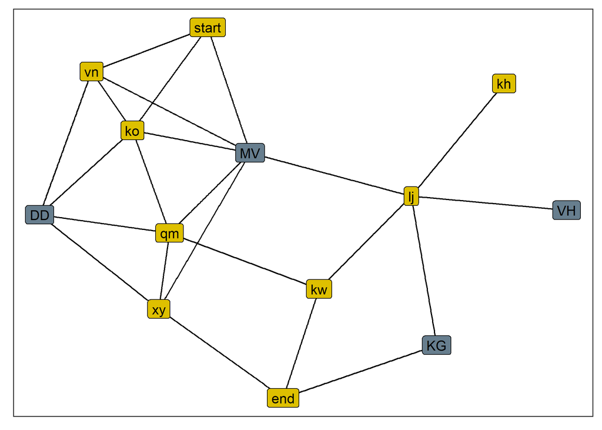

```r
p_load(tidygraph, ggraph)

input <- advent_input(12)

once <- c("start", "end", "ko", "kw", "lj", "qm", "vn", "xy", "kh")
multi <- c("DD", "KG", "MV", "VH")

x <- input %>%
  separate(x, into = c("from", "to"), sep = "-") %>%
  mutate(dist = 1)


graph_routes <- as_tbl_graph(x)

graph_routes %>%
  ggraph(layout = "kk") +
  geom_edge_link() +
  geom_node_label(aes(label = name,
                      fill = ifelse(name %in% once, "blue", "orange")),
                  size = 4, show.legend = FALSE) +
  scale_fill_manual(values = c("#DEC000FF", "#677E8EFF"))
```

## Puzzle #1

```r
connections <- x %>%
  select(from = to, to = from) %>%
  bind_rows(x %>% select(-dist)) %>%
  group_by(from) %>%
  summarize(connections = list(to)) %>%
  deframe()

bfs <- function(node, visited_small = NULL, part1 = FALSE) {
  # Base case
  if (node == "end") {
    return(list(node))
  }
  # start can't be revisited
  if (node == "start" && "start" %in% visited_small) {
    return(NULL)
  }

  if (str_to_upper(node) != node) {
    visited_small <- c(visited_small, node)
  }

  possible_next <- connections[[node]]

  # part 1 = no revisiting, part 2 = 1 revisit
  if (part1 || any(duplicated(visited_small))) {
    possible_next <- setdiff(possible_next, visited_small)
  }

  map(possible_next, bfs, visited_small = visited_small, part = part1) %>%
    do.call(c, .) %>%
    map(~ c(node, .))
}
```

Answer #1: **3292** ⭐

## Puzzle #2

Answer #1: **89592** ⭐

# Day 13: Transparent Origami

## Puzzle #1

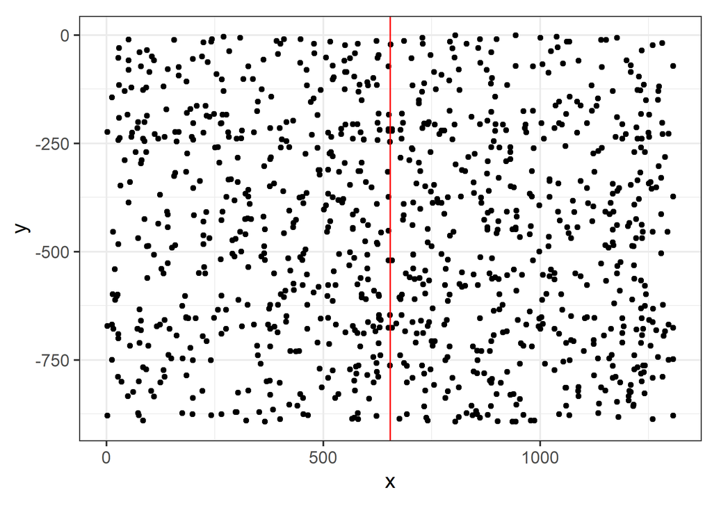

```r
input <- advent_input(13)

folds <- input %>%
  slice(985:996) %>%
  mutate(x = str_extract(x, '(x|y)=[0-9]*$')) %>%
  separate(x, c("direction", "fold"), "=") %>%
  mutate(fold = parse_number(fold))

points <- input %>%
  slice(1:983) %>%
  separate(x, c("x", "y"), convert = TRUE) %>%
  mutate(y = y * -1)

points %>%
  ggplot(aes(x, y)) +
  geom_point() +
  geom_vline(xintercept = folds$fold[1], color = "red") +
  coord_fixed()
```

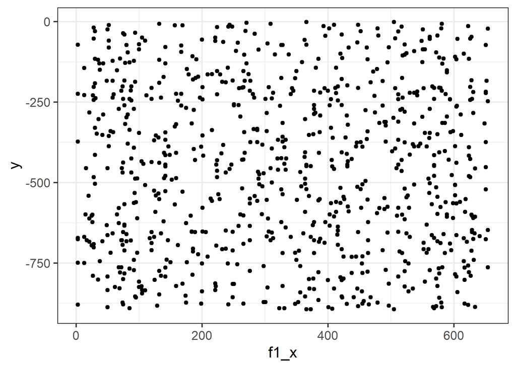

```r
points2 <- points %>%
  mutate(f1_x = case_when(x > folds$fold[1] ~ folds$fold[1] - (x - folds$fold[1]),
                        x < folds$fold[1] ~ as.numeric(x)))

points2 %>%
  ggplot(aes(f1_x, y)) +
  geom_point()
```

```r
part1 <- points2 %>%
  distinct(f1_x, y) %>%
  count()
```

Answer #1: **810** ⭐

## Puzzle #2

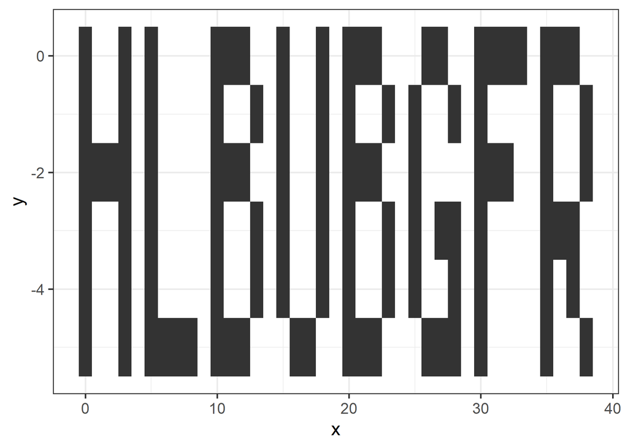

```r
points2 <- points %>%
  mutate(x = case_when(x > folds$fold[1] ~ folds$fold[1] - (x - folds$fold[1]),
                        x < folds$fold[1] ~ as.numeric(x)),
         y = case_when(y < -folds$fold[2] ~ -folds$fold[2] + (-folds$fold[2] - y),
                        y > -folds$fold[2] ~ y),
         x = case_when(x > folds$fold[3] ~ folds$fold[3] - (x - folds$fold[3]),
                        x < folds$fold[3] ~ x),
         y = case_when(y < -folds$fold[4] ~ -folds$fold[4] + (-folds$fold[4] - y),
                        y > -folds$fold[4] ~ y),
         x = case_when(x > folds$fold[5] ~ folds$fold[5] - (x - folds$fold[5]),
                        x < folds$fold[5] ~ x),
         y = case_when(y < -folds$fold[6] ~ -folds$fold[6] + (-folds$fold[6] - y),
                        y > -folds$fold[6] ~ y),
         x = case_when(x > folds$fold[7] ~ folds$fold[7] - (x - folds$fold[7]),
                        x < folds$fold[7] ~ x),
         y = case_when(y < -folds$fold[8] ~ -folds$fold[8] + (-folds$fold[8] - y),
                        y > -folds$fold[8] ~ y),
         x = case_when(x > folds$fold[9] ~ folds$fold[9] - (x - folds$fold[9]),
                        x < folds$fold[9] ~ x),
         y = case_when(y < -folds$fold[10] ~ -folds$fold[10] + (-folds$fold[10] - y),
                        y > -folds$fold[10] ~ y),
         y = case_when(y < -folds$fold[11] ~ -folds$fold[11] + (-folds$fold[11] - y),
                        y > -folds$fold[11] ~ y),
         y = case_when(y < -folds$fold[12] ~ -folds$fold[12] + (-folds$fold[12] - y),
                        y > -folds$fold[12] ~ y))


points2 %>%
  ggplot(aes(x, y)) +
  geom_tile()
```

Answer #2: **HLBUBGFR** ⭐

# Day 14: Extended Polymerization

## Puzzle #1

# **Reflections on Advent of Code**

These challenges were difficult. I learned some new things like `lead`, `lag`, `cumsum`, `scipen`, the utilty of user functions, and that trial-and-error only goes so far. I hope to be better at this next year. Overall, it was a good experience and it was interesting to see other people’s solutions.